# Case Study: Time Series Forecasting of Monthly Sunspots

Joshua Zhong

01/17/2024

# 1 Introduction

This dataset presents the monthly mean total sunspot numbers from January 1749 up to the last elapsed month, with provisional values for recent 3 months. The monthly mean is calculated as the arithmetic mean of daily total sunspot numbers for each calendar month. The data extends back to 1749, the year from which consistent daily observations became available, allowing for reliable monthly averages. Prior to 1749, only yearly means are present due to the sparsity of data.

Missing values in the dataset are denoted by a value of -1. The dataset includes standard deviation values derived from daily observations, providing a measure of variability and the standard error on the monthly means, allowing for an assessment of the precision of the data. In addition, February 1824 is an exception in this historical record; lacking daily values, its monthly mean was interpolated from neighboring months by the compiler, R. Wolf.

## 1.1 Data cleaning

To get an idea of what our data set looks like, here are the first 6 observations in the data set.

Currently needs formatting

| X1749.01.1749.042…96.7…1.0…..1.1 |
| --- |
| 1749;02;1749.123; 104.3; -1.0; -1;1 |
| 1749;03;1749.204; 116.7; -1.0; -1;1 |
| 1749;04;1749.288; 92.8; -1.0; -1;1 |
| 1749;05;1749.371; 141.7; -1.0; -1;1 |
| 1749;06;1749.455; 139.2; -1.0; -1;1 |
| 1749;07;1749.538; 158.0; -1.0; -1;1 |

The data required reformatting from a single variable into a data frame with separate entries for year, month, mean sunspot numbers, and other relevant variables. The cleaned and formatted data is displayed below:

Properly formatted data (continued below)

| Year | Month | Date | Mean.Sunspots | Mean.Standard.Deviation |
| --- | --- | --- | --- | --- |
| 1749 | 1 | 1749 | 96.7 | -1 |
| 1749 | 2 | 1749 | 104.3 | -1 |
| 1749 | 3 | 1749 | 116.7 | -1 |
| 1749 | 4 | 1749 | 92.8 | -1 |
| 1749 | 5 | 1749 | 141.7 | -1 |
| 1749 | 6 | 1749 | 139.2 | -1 |

| Observation.Count | Provisional.Marker |
| --- | --- |
| -1 | 1 |
| -1 | 1 |
| -1 | 1 |
| -1 | 1 |
| -1 | 1 |
| -1 | 1 |

## 1.2 Data Set Description

This data set records monthly mean and standard deviation for daily sunspot observations compiled into a per calendar month basis.

The link to the raw CSV file in posted on GitHub: https://raw.githubusercontent.com/JZhong01/STA321/main/Topic%206%20(Time%20Series)/Updated_Sunspot_Data.csv.

- Year: This records the year of an observation based on the Gregorian calendar date.
- Month: This records the month of an observation based on the Gregorian calendar date.
- Date: This is the date in the form of a fraction of year based on the middle of the month. We will largely ignore this column.
- Mean Sunspots: Monthly mean total sunspot number, calculated by taking total sunspot observations divided by total days in the month.
- Mean Standard Deviation: Monthly mean standard deviation of input sunspot number from individual stations.
- Observation Count: This records the number of observations in each given month - used to calculate the monthly mean observed sunspot count.
- Provisional Marker: This denotes whether the data is definitive (confirmed) or still provisional and subject to possible revision. 1 marks definitive, 0 marks provisional.

The dataset includes some missing values. However, because most of these missing values occurred in the distant past and falls outside of the most recent 200 observations - what we plan on using for the majority of this study - we proceed without imputing, removing, or interpolating the missing values.

# 2 Research Question

Research Question: Given the historical trends in sunspot activity, can we forecast future sunspot numbers using time series analysis, and identify any significant patterns or cycles in the data?

The hypotheses of the study are that:

# 3 Time Series

Time series analysis is particularly well-suited for our sunspot number data set because it involves observations recorded sequentially over time. Time Series data is typically characterized by trends, seasonality, and error/residual components. By employing time series analysis, we aim to dissect these underlying patterns: the long-term trend shows the general movement of sunspot numbers over the years, while the seasonal component would reveal any regular fluctuations within a given period (e.g., an 11-year solar cycle). The irregular component, or error term, encapsulates random variations and anomalies not explained by trend or seasonality.

Decomposition of the time series into these constituent elements enables a clearer understanding of the behavior of sunspot activity and aids in identifying any anomalies or shifts in patterns. Once we have isolated these components, we can use them to construct models that forecast future sunspot numbers. Trend and seasonality can inform predictive models, while understanding the error term can improve the accuracy and reliability of our forecasts. By anticipating future solar activity, we can contribute valuable insights into potential solar impacts on Earth’s climate and space weather-related phenomena.

## 3.1 Define Time Series Object

The code snippet provided defines a time series object, sunspots_ts, which represents the monthly mean sunspot numbers for a specific subset of the sunspots data frame. This subset spans from the 3100th to the 3300th observation, capturing the 201 most recent observations. The start parameter for the time series is dynamically set to correspond to the year and month of the 3100th observation in the sunspots dataset, ensuring that the time series aligns with the actual chronological order of the data. The frequency parameter is set to 12 to reflect the monthly periodicity of the data. The resulting time series object is then plotted with the given labels and title, showing the variation in mean monthly sunspot numbers for the selected period.

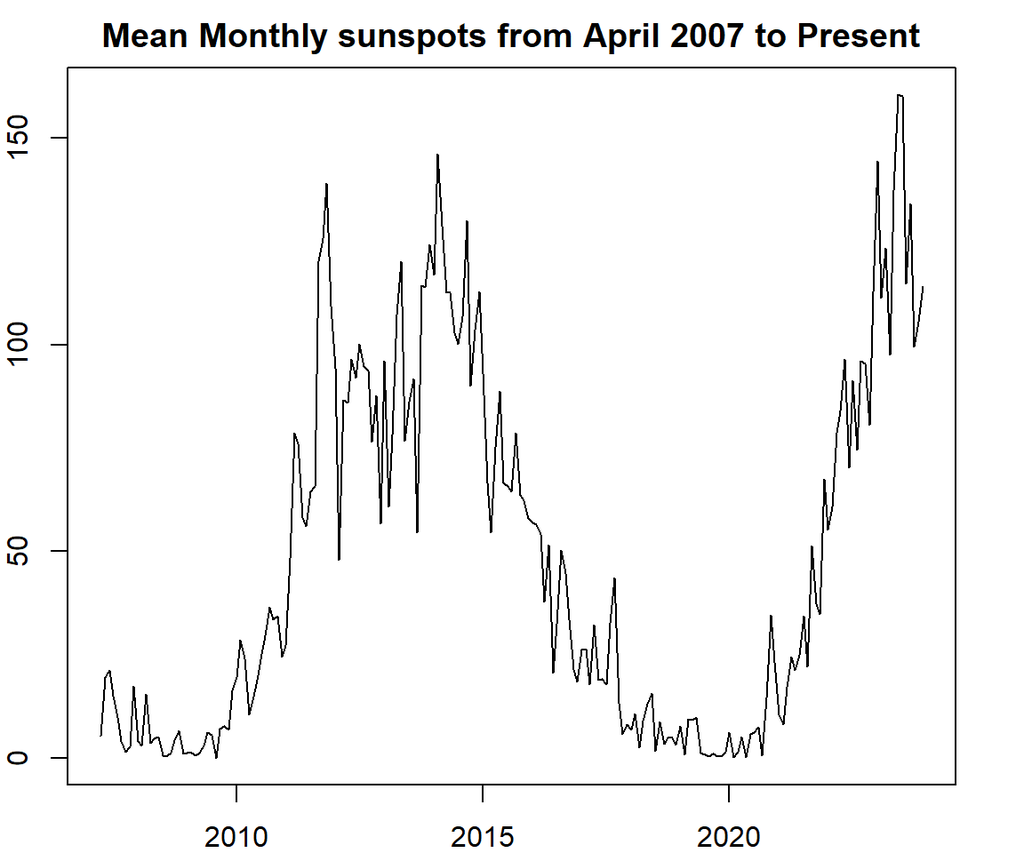

```r
sunspot_200 <- sunspots[3100:3300,]

sunspots_ts <- ts(sunspot_200$Mean.Sunspots, start=c(sunspots$Year[3100], sunspots$Month[3100]), frequency=12)

par(mar = c(2,2,2,2))

plot(sunspots_ts, main = "Mean Monthly sunspots from April 2007 to Present", ylab = "Month", xlab = "Mean Monthly sunspot")
```

# 4 Decomposition

To forecast data, we will be using decomposition methods. Decomposition in time series analysis refers to the process of breaking down observed data into 3 distinct components to identify and isolate systematic patterns and structures. These 3 components are trend, seasonality, and residual effects. Trend represents long-term progression, seasonality reflects regular and predictable cycles, and residual or error effects encompass the remaining random error due to chance. Decomposition allows us to identify and separate the data into these categories to better grasp the underlying behaviors in the data, which helps improve forecasting accuracy. There are 2 methods of decomposition that we’ll be exploring in this case study: Classical and STL Decomposition.

## 4.1 Classical Decompositiion

Classical decomposition splits a time series into a trend, seasonal, and irregular component using moving averages. It typically assumes that the seasonal component repeats from year to year and that the pattern does not change over time. There are two types of classical decomposition:

- Additive Model: $Y_t = T_t + S_t + R_t$ where $Y_t$ is the data, $T_t$ represents the trend, $S_t$ represents the seasonal component and $R_t$ is the residual.
- Multiplicative Model: $Y_t = T_t * S_t * R_t$ where $Y_t$ is the data, $T_t$ represents the trend, $S_t$ represents the seasonal component and $R_t$ is the residual.

In classical decomposition, the trend is usually estimated by applying a moving average filter, and the seasonal component is computed by averaging the de-trended data for each season. The remainder is then obtained by subtracting (for additive) or dividing (for multiplicative) the estimated trend and seasonal components from the original data.

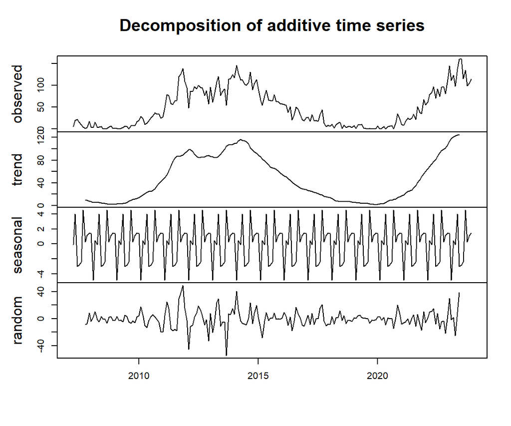

## 4.2 STL Decomposition

We applied Seasonal-Trend Decomposition using Loess (STL) to analyze the sunspot time series. STL is particularly advantageous for this analysis because it does not assume that the data is stationary. Instead, STL can adapt to non-linear trends and changing seasonal patterns, making it more flexible for the analysis of complex time series data such as sunspots.

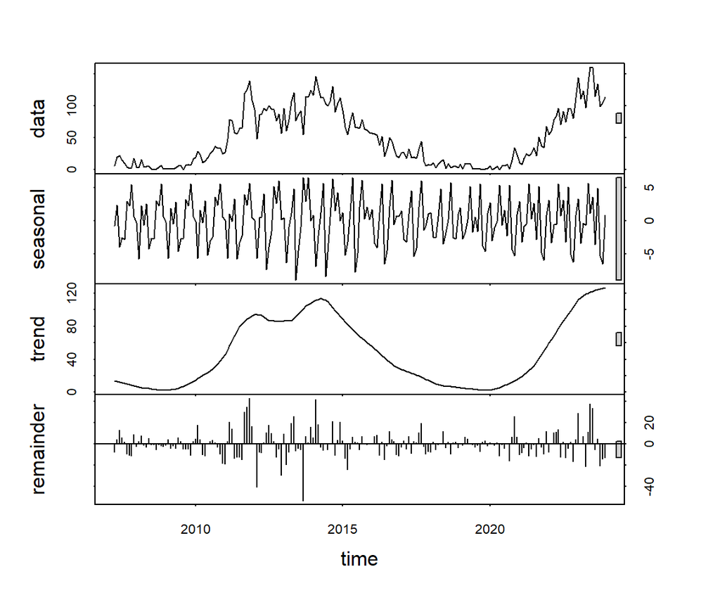

The third panel, depicting the trend component, reveals significant long-term changes in sunspot activity. There is a clear increase in sunspot numbers beginning around 2008, followed by a dip in the mid-2010s and a sharp rise again starting around 2020. These changes suggest the presence of larger cycles or shifts in solar activity that extend beyond the annual variations captured in the seasonal component. The non-linear nature of the trend is crucial, as it shows that sunspot activity does not follow a simple linear progression but rather undergoes more complex shifts over time.

## 4.3 Why We Chose STL Decomposition with Additive Decomposition

In summary, STL decomposition with additive decomposition was chosen because it is well-suited to handling both the stable seasonality and the more complex, non-linear trend shifts in sunspot activity. Its flexibility allows it to adapt to irregularities and sudden changes in the data, making it an ideal method for this type of time series analysis.

# 5 Forecasting

In order to forecast we begin with the division of the time series data into training and testing sets. The training set is used to fit the model, while the testing set is reserved to evaluate the model’s predictive performance. By using different sample sizes for the training set, we can assess how the amount of historical data impacts the model’s accuracy. For instance, larger training sets may capture more of the underlying patterns, potentially leading to more accurate forecasts. However, there’s also a risk of overfitting, which can negatively impact out-of-sample predictions.

## 5.1 Training and Testing Data

The last 12 months of data were reserved for testing. We split the data into four different training set sizes: n = 189, 146, 96, and 48 months. These subsets were created to evaluate the impact of sample size on the forecast accuracy. The seasonal naive forecast was then applied to each training set.

```r
##
train.data01 = sunspot_200[1:(201-12), 4]
train.data02 = sunspot_200[44:(201-12), 4]
train.data03 = sunspot_200[94:(201-12), 4]
train.data04 = sunspot_200[142:(201-12), 4]
## last 7 observations
test.data = sunspot_200[(201-11):201,4]
##
train01_ts = ts(train.data01, frequency = 12, start = c(2007, 4))
train02_ts = ts(train.data02, frequency = 12, start = c(2010, 11))
train03_ts = ts(train.data03, frequency = 12, start = c(2015, 1))
train04_ts = ts(train.data04, frequency = 12, start = c(2019, 1))
##
stl01 = stl(train01_ts, s.window = 12)
stl02 = stl(train02_ts, s.window = 12)
stl03 = stl(train03_ts, s.window = 12)
stl04 = stl(train04_ts, s.window = 12)
## Forecast with decomposing
fcst01 = stlf(train01_ts, h = 12, method = "naive")
fcst02 = stlf(train02_ts, h = 12, method = "naive")
fcst03 = stlf(train03_ts, h = 12, method = "naive")
fcst04 = stlf(train04_ts, h = 12, method = "naive")
```

## 5.2 Performing Error Analysis

After applying the seasonal naive forecast to each training set, we calculated three key error metrics: Mean Absolute Error (MAE), Mean Squared Error (MSE), and Mean Absolute Percentage Error (MAPE). These metrics help quantify how well the model predicted the future sunspot numbers.

Error comparison between forecast results with different sample sizes

MAE

MSE

MAPE

n.189

20.118

724.759

0.185

n.146

20.118

726.015

0.186

21.165

768.385

0.197

24.587

983.877

0.242

The table below shows the forecast errors for each training set size. We see that as the training sample size decreases, the forecasting errors generally increase. This trend is evident in the MSE and MAPE values, where smaller sample sizes produce larger errors.

Smaller training sets lead to increased forecast errors because they capture less historical variability and fewer trends. The model has fewer past observations to learn from, making it harder to predict future values accurately. Larger datasets, in contrast, offer more context and historical patterns, leading to more accurate predictions.

## 5.3 Error Curves

The following plots visualize the MSE and MAPE errors across different sample sizes.

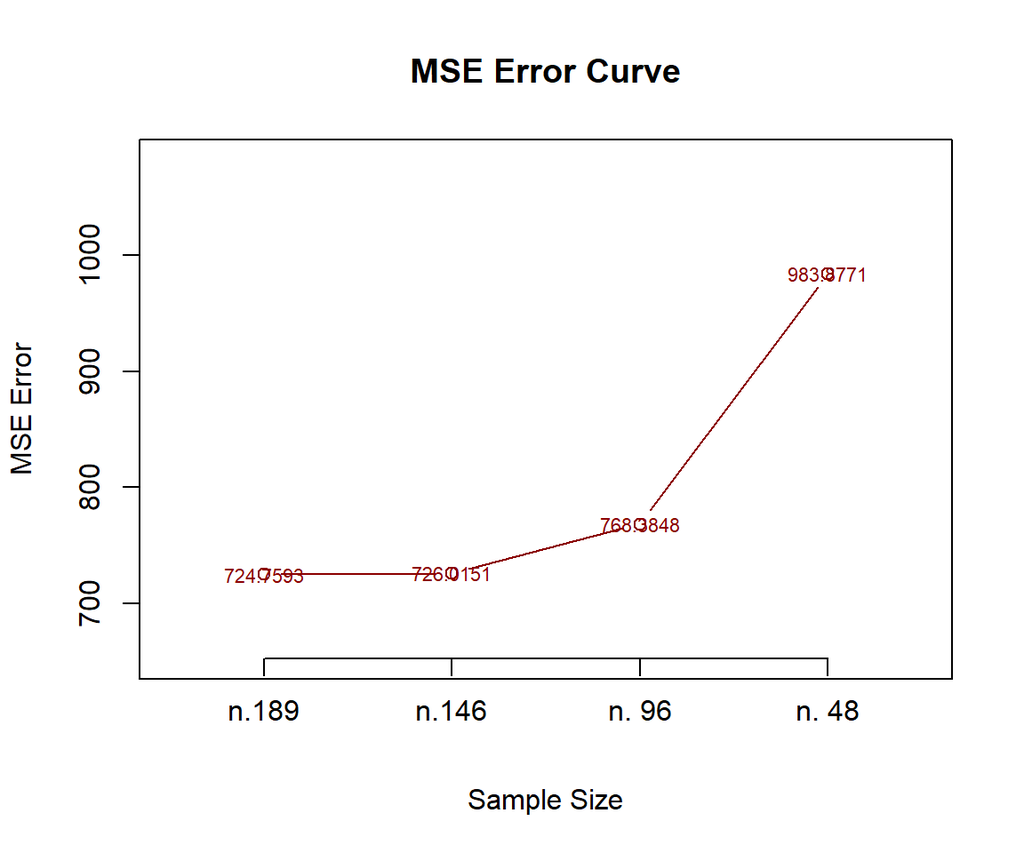

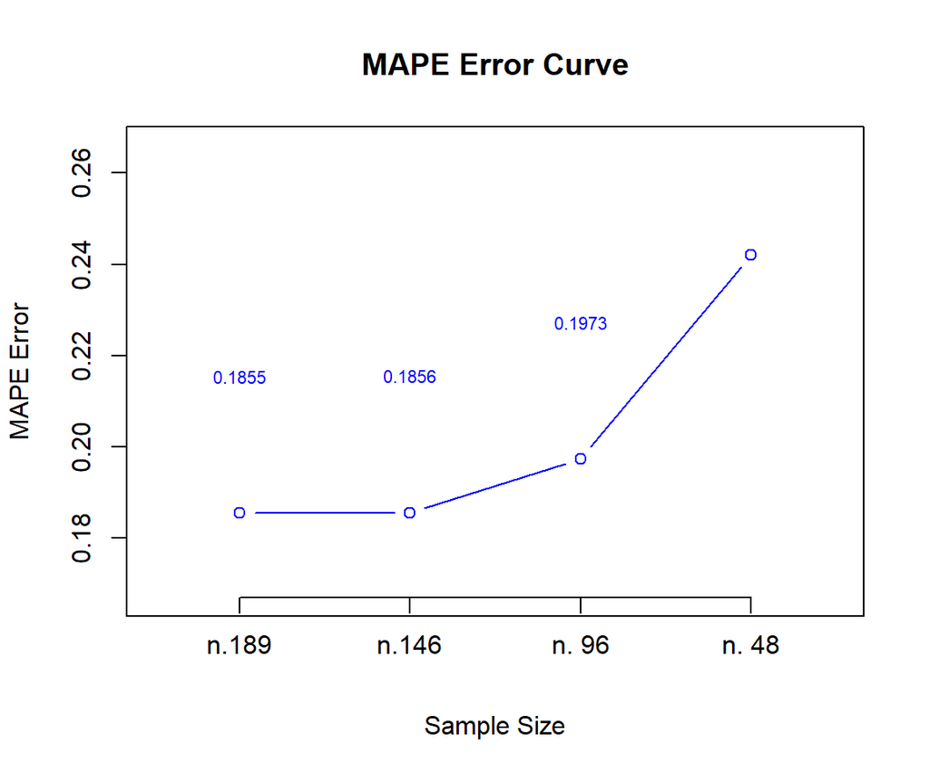

Both curves show an upward trend in error as the training set size decreases, indicating that larger sample sizes yield more accurate forecasts.

## 5.4 Discussion of Forecasting Results

The seasonal naive forecasting model provides a baseline for evaluating the predictability of future sunspot numbers. However, the results indicate that the model has limited accuracy, particularly for smaller training sets.

For the largest training set (n = 189), the Mean Squared Error (MSE) is 724.76, and the Mean Absolute Percentage Error (MAPE) is 0.185, which is reasonable for a naive forecasting model. As the sample size decreases, however, the errors increase noticeably. For the smallest sample size (n = 48), the MSE rises to 983.88, and the MAPE increases to 0.242. This demonstrates that when the model has less historical context, its ability to make accurate predictions is significantly diminished.

Overall, the model performed moderately well for larger training sets, but its performance degraded as the available historical data decreased. The errors suggest that while the seasonal naive method captures regular seasonal fluctuations, it lacks the ability to model the non-linear trend shifts that are evident in the sunspot data. The relatively high errors, particularly for smaller sample sizes, suggest that a more sophisticated model is needed to improve forecasting accuracy, especially given the complex dynamics of sunspot activity.

# 6 Limitations

In this analysis, we applied the seasonal naive forecasting model to predict future sunspot numbers. While this approach provides a simple baseline, the results reveal some key limitations that impact its accuracy, particularly for complex time series like sunspot activity.

## 6.1 Naive Forecasting

The seasonal naive method assumes that future values will be the same as the most recent observed value from the same season. While this approach works well for capturing regular, repeating seasonal patterns, it struggles in scenarios where the data exhibits non-linear trends or sudden shifts, as observed in the sunspot data. The high error rates, particularly for smaller sample sizes, indicate that the model does not adapt well to changes in the underlying trend or unexpected deviations in sunspot activity.

## 6.2 ARIMA

An alternative to the naive model is ARIMA (AutoRegressive Integrated Moving Average), which can handle both trends and autocorrelation in time series data. ARIMA models are flexible and could provide better results for the sunspot data, particularly by addressing the non-linear trends identified in the STL decomposition. However, ARIMA requires the data to be stationary.

To determine if the sunspot data is stationary, we perform the Augmented Dickey-Fuller (ADF) test, which checks for the presence of a unit root. If the p-value is less than 0.05, we reject the null hypothesis and conclude that the data is stationary. Otherwise, differencing would be required.

### 6.2.1 Testing for Stationarity

To determine if the sunspot data is stationary, we perform the Augmented Dickey-Fuller (ADF) test, which checks for the presence of a unit root. If the p-value from the test is less than 0.05, we can reject the null hypothesis that the data is non-stationary and conclude that it is stationary. If the data is non-stationary, transformations such as differencing would be required before applying ARIMA.

```
FALSE
FALSE   Augmented Dickey-Fuller Test
FALSE
FALSE data:  sunspots_ts
FALSE Dickey-Fuller = -0.84366, Lag order = 5, p-value = 0.9562
FALSE alternative hypothesis: stationary
```

Based on the ADF test, the p-value is above 0.05, indicating that the data is non-stationary. This suggests that differencing would be necessary to apply ARIMA. However, because our focus is on decomposition through STL and not on stationary transformations, ARIMA was not applied in this analysis.

While ARIMA could potentially improve forecasts by addressing stationarity, it was not pursued due to the need for transformation. Future research could explore this model after applying differencing.

## 6.3 Holt-Winters

The Holt-Winters exponential smoothing method could be a valuable tool in future studies for forecasting sunspot numbers, especially given its ability to model both trend and seasonality simultaneously. It is particularly effective for time series with consistent seasonal patterns and linear trends, which makes it a strong candidate for sunspot data where cyclic behavior is prominent.

However, in this study, Holt-Winters was not pursued for several reasons. The focus was placed on using STL decomposition, as it allows for a more flexible, component-based approach that isolates non-linear trends and variable seasonality. This approach aligns better with the research objectives to identify patterns and changes in sunspot variability over time. By using STL, we were able to achieve a detailed breakdown of the time series, providing clearer insights into both the seasonal and trend components before applying a naive forecasting method.

# 7 Summary

In this case study, STL decomposition was used to analyze and forecast sunspot activity. While STL effectively decomposed the data into trend, seasonal, and residual components, the resulting forecasts using the seasonal naive model exhibited high Mean Squared Error (MSE) and Mean Absolute Percentage Error (MAPE), suggesting limitations in forecasting accuracy. The poor performance may be attributed to the model’s inability to capture sudden shifts and non-linear trends, particularly the sharp increase in sunspot activity observed after 2020.

The study highlights that STL’s assumptions, such as linearity and homoscedasticity, may not hold throughout the data, especially given the complex dynamics of sunspot activity. The high forecast errors underscore the need for more advanced models, such as ARIMA or Holt-Winters, which could better handle non-linearities and trend shifts.

This analysis demonstrates that while STL provides valuable insights into underlying patterns, further refinement and exploration of more sophisticated models are necessary to improve forecasting performance and capture the complex behaviors in time series data.

# 8 References

Gupta, D. (2018). *Applied Analytics through Case Studies Using SAS and R*. APress.

Ciaburro G. (2018). *Regression Analysis with R: Design and Develop Statistical Nodes to Identify Unique Relationships Within Data at Scale*. Packt Publishing.

“Sunspot data from the World Data Center SILSO, Royal Observatory of Belgium, Brussels”